# Functions and Tidy Data

Uzezi Okinedo

10/5/2020

```r
# Loading all libraries

library(dplyr)
library(tidyr)
library(readr)
library(lubridate)
```

```r
library(ggplot2)
library(forcats)
```

**1.** Write a function that takes a vector and returns one bootstrapped sample from said vector. Demonstrate that it works.

```r
get_01_boot_samp <- function(vec){
  #get one bootstrapped sample from a said vector
   one_boot <-  sample(vec,
                    size = length(vec),
                    replace = TRUE)
  # return output
  return(one_boot)

}

#to demonstrate function with vole_vaso (a vector)
vole_vaso <- c(98,96,94,88,86,82,77,74,70,60,
           59,52,50,47,40,35,29,13,6,5)

# check if function works
get_01_boot_samp(vole_vaso)
```

```
##  [1] 40 94 77  6 82 13 50 88 40 88 74 35 35 88 86 60 77 47 52 52
```

**2.** Write a function that given a vector of values a request for some number of bootstraps (let’s call the parameter R), and a sample statistic function (e.g., mean, IQR, etc.) returns R number of values of that statistic. Have it default to R = 1000 and the function is mean. Show this works for 10 bootstrapped replicate draws of a mean from some vector. Do the values look reasonable? Compare to the actual mean of the vector.

make sure you are using the function(s) you wrote in #1

```r
# function for a vector of values
# Request for a number of bootstraps (R)
# Set R = 1000 as default
get_01k_boot_mean <- function(vec, R = 1000) {

  # calculate bootstrapped mean of a sample
  # Use get_01_boot_samp() from question 1
  boot_mean <- replicate(R,
                         mean(get_01_boot_samp(vec)))
  # return output
  return(boot_mean)
}
```

```r
# check if function works for 10 replicates of a sample
# set R = 10
get_01k_boot_mean(vole_vaso, R = 10)
```

```
##  [1] 62.65 63.75 56.25 60.35 58.10 65.15 43.30 70.05 59.80 50.60
```

The actual mean of the vector is 58.05. Therefore, these values look reasonable.

**3.** Write a function that, given a vector of values a request for some number of bootstraps, and a sample statistic function, returns the original value of the statistic as applied to the vector, the mean of the statistic generated by the bootstrapped reps, the upper and lower 95% CI of the bootstrapped statistic (e.g., the 0.025 and 0.975 quantile), and the bias (i.e., the original value of the statistic - the mean of the bootstrapped statistic). make sure you are using the function(s) you wrote in #1 and/or #2

```r
# A function given a vector of values,
# request for some number of bootsraps (R)
# a sample statistic function
a_function <- function(vec, m, R = 1000) {
  # Returns the original value of the statistics (mean)
  original_mean <- mean(vec)
  # returns the bootstrap mean using function created in question 2
  boot_mean <- get_01k_boot_mean(vec, R)
  # returns upper confidence interval
  upper_CI <- quantile(boot_mean, probs = 0.975)
  #returns lower confidence interval
  lower_CI <- quantile(boot_mean, probs = 0.025)
  # returns bias
  bias <- original_mean - boot_mean

  # define and summarise output
  out <- data.frame(original_mean = mean(vec),
                    boot_mean = get_01k_boot_mean(vec, R),
                    upper_CI = quantile(boot_mean, probs = 0.975),
                    lower_CI = quantile(boot_mean, probs = 0.025),
                    bias = original_mean - boot_mean)

  return(out)

}

# test function on a vector (vole_vaso)
a_function(vole_vaso, R = 10)
```

```
##    original_mean boot_mean upper_CI lower_CI   bias
## 1          58.05     40.50 71.22875   50.925 -14.90
## 2          58.05     58.60 71.22875   50.925  -6.60
## 3          58.05     63.30 71.22875   50.925  -5.20
## 4          58.05     61.30 71.22875   50.925   8.25
## 5          58.05     73.85 71.22875   50.925  -0.65
## 6          58.05     46.40 71.22875   50.925  -1.80
## 7          58.05     60.00 71.22875   50.925  -4.85
## 8          58.05     60.15 71.22875   50.925   3.25
## 9          58.05     65.70 71.22875   50.925  -3.20
## 10         58.05     57.35 71.22875   50.925  -7.25
```

**4.** FiveThirtyEight keeps a great archive of poll data at https://projects.fivethirtyeight.com/polls/. The presidential general election polling data is freely available at https://projects.fivethirtyeight.com/polls-page/president_polls.csv with question, poll id, and cycle defining a unique poll.

**4a.** Download and look at the data. Is it long or wide?

```r
# download president poll data
download.file(url = "https://projects.fivethirtyeight.com/polls-page/president_polls.csv",
              destfile = "raw_data/president_polls.csv")

# read data into an object
president_polls <- read_csv("raw_data/president_polls.csv")
# view data
president_polls
```

```
## # A tibble: 9,377 x 38
##    question_id poll_id cycle state pollster_id pollster sponsor_ids sponsors
##          <dbl>   <dbl> <dbl> <chr>       <dbl> <chr>          <dbl> <chr>
##  1      132305   70723  2020 <NA>         1610 USC Dor~          NA <NA>
##  2      132305   70723  2020 <NA>         1610 USC Dor~          NA <NA>
##  3      132306   70723  2020 <NA>         1610 USC Dor~          NA <NA>
##  4      132306   70723  2020 <NA>         1610 USC Dor~          NA <NA>
##  5      132307   70723  2020 <NA>         1610 USC Dor~          NA <NA>
##  6      132307   70723  2020 <NA>         1610 USC Dor~          NA <NA>
##  7      132272   70715  2020 Geor~         383 Public ~          NA <NA>
##  8      132272   70715  2020 Geor~         383 Public ~          NA <NA>
##  9      132284   70718  2020 <NA>           11 ABC New~         378 The Was~
## 10      132284   70718  2020 <NA>           11 ABC New~         378 The Was~
## # ... with 9,367 more rows, and 30 more variables: display_name <chr>,
## #   pollster_rating_id <dbl>, pollster_rating_name <chr>, fte_grade <chr>,
## #   sample_size <dbl>, population <chr>, population_full <chr>,
## #   methodology <chr>, office_type <chr>, seat_number <dbl>, seat_name <lgl>,
## #   start_date <chr>, end_date <chr>, election_date <chr>,
## #   sponsor_candidate <chr>, internal <lgl>, partisan <chr>, tracking <lgl>,
## #   nationwide_batch <lgl>, ranked_choice_reallocated <lgl>, created_at <chr>,
## #   notes <chr>, url <chr>, stage <chr>, race_id <dbl>, answer <chr>,
## #   candidate_id <dbl>, candidate_name <chr>, candidate_party <chr>, pct <dbl>
```

This is a long data

**4b.** Get just the polling data for this last week (from 9/29 to today). Filter on start_date. Also filter down to just Biden and Trump (see candidate_name or answer). Extra credit for using {lubridate} for this, but you can just do a messy %in% string match.

```r
# Covert "start_date" column to Date using lubridate
president_polls$start_date <- as.Date(president_polls$start_date, format = "%m/%d/%Y")

polls <- president_polls %>%
  #filtered start dates from 9/29 and above and selected "Donald Trump" and "Joseph R. Biden"using lubridate.
  filter(start_date >= "0020-09-29") %>%
  filter(candidate_name %in% c("Donald Trump", "Joseph R. Biden Jr."))

# view polls
polls
```

```
## # A tibble: 272 x 38
##    question_id poll_id cycle state pollster_id pollster sponsor_ids sponsors
##          <dbl>   <dbl> <dbl> <chr>       <dbl> <chr>          <dbl> <chr>
##  1      132272   70715  2020 Geor~         383 Public ~          NA <NA>
##  2      132272   70715  2020 Geor~         383 Public ~          NA <NA>
##  3      132284   70718  2020 <NA>           11 ABC New~         378 The Was~
##  4      132284   70718  2020 <NA>           11 ABC New~         378 The Was~
##  5      132285   70718  2020 <NA>           11 ABC New~         378 The Was~
##  6      132285   70718  2020 <NA>           11 ABC New~         378 The Was~
##  7      132286   70718  2020 <NA>           11 ABC New~         378 The Was~
##  8      132286   70718  2020 <NA>           11 ABC New~         378 The Was~
##  9      132287   70718  2020 <NA>           11 ABC New~         378 The Was~
## 10      132287   70718  2020 <NA>           11 ABC New~         378 The Was~
## # ... with 262 more rows, and 30 more variables: display_name <chr>,
## #   pollster_rating_id <dbl>, pollster_rating_name <chr>, fte_grade <chr>,
## #   sample_size <dbl>, population <chr>, population_full <chr>,
## #   methodology <chr>, office_type <chr>, seat_number <dbl>, seat_name <lgl>,
## #   start_date <date>, end_date <chr>, election_date <chr>,
## #   sponsor_candidate <chr>, internal <lgl>, partisan <chr>, tracking <lgl>,
## #   nationwide_batch <lgl>, ranked_choice_reallocated <lgl>, created_at <chr>,
## #   notes <chr>, url <chr>, stage <chr>, race_id <dbl>, answer <chr>,
## #   candidate_id <dbl>, candidate_name <chr>, candidate_party <chr>, pct <dbl>
```

**4c.** OK, this is your sample. What’s the bootstrapped average percentage for each candidate for nationwide polls (state == "")? Note, this answer will not match 538 given their weighting by poll trustworthiness.

```r
# created a wide dataframe and made seperate columns for each candidate with values from the average national polls as the rows.

polls_wide <- polls %>%
  # pivot wider function
  pivot_wider(names_from = candidate_name,
              values_from = pct,
              values_fill = list(density = 0))

# to get the bootstrapped average percentage for each candidate
polls_wide %>%

  # group by state
  group_by(state) %>%
  # determine bootstrapped average percentage for each candidate using function from question 2
  summarise(boot_avg_pct_trump = get_01_boot_samp(mean(`Donald Trump`, na.rm = TRUE)), boot_avg_pct_biden = get_01_boot_samp(mean(`Joseph R. Biden Jr.`, na.rm = TRUE)))
```

```
## # A tibble: 23 x 3
##    state     boot_avg_pct_trump boot_avg_pct_biden
##    <chr>                  <int>              <int>
##  1 Alabama                   30                 34
##  2 Arizona                   31                 45
##  3 Colorado                  16                 48
##  4 Florida                    7                 22
##  5 Georgia                   24                 15
##  6 Iowa                      36                 22
##  7 Maryland                  10                  6
##  8 Michigan                  11                  3
##  9 Minnesota                 33                 14
## 10 Missouri                  18                 19
## # ... with 13 more rows
```

**4d.** What is the average difference between the two candidates by state and national polls? Note, you’ll need to make this a wide data frame to answer! And, well, try the pivot without this advice first, but then….

make a unique ID by pasting together the question_id, poll_id, and state. Then select the ID, state, answer, and pct. Also filter out NA diffs

```r
# make a unique ID by pasting together question_id, poll_id and state using mutate and paste
new_polls_wide <- polls_wide %>%
  group_by(state) %>%
  mutate('question_id-poll_id-state' = paste(as.character(question_id), as.character(poll_id), as.character(state), sep = "_")) %>%
  # group new dataframe by new ID
  group_by(`question_id-poll_id-state`) %>%
  # calculate average differences between the two candidates nationwide
  summarise(Trump = na.omit(`Donald Trump`), Biden = na.omit(`Joseph R. Biden Jr.`), difference = Trump - Biden, average = (Trump + Biden)/2, avg_difference = difference/average)
# view data with average differences
new_polls_wide
```

```
## # A tibble: 135 x 6
## # Groups:   question_id-poll_id-state [135]
##    `question_id-poll_id-state` Trump Biden difference average avg_difference
##    <chr>                       <dbl> <dbl>      <dbl>   <dbl>          <dbl>
##  1 130599_70105_NA              41    54        -13      47.5        -0.274
##  2 130607_70108_Georgia         44.9  46.6       -1.7    45.8        -0.0372
##  3 130619_70111_NA              38    43         -5      40.5        -0.123
##  4 130620_70111_NA              40    47         -7      43.5        -0.161
##  5 130621_70111_NA              41    50         -9      45.5        -0.198
##  6 130623_70112_New Hampshire   45.3  53.1       -7.8    49.2        -0.159
##  7 130649_70122_NA              45.9  48.6       -2.7    47.2        -0.0571
##  8 130657_70129_Michigan        44    50         -6      47          -0.128
##  9 130667_70136_NA              41    51        -10      46          -0.217
## 10 130682_70142_NA              40    47         -7      43.5        -0.161
## # ... with 125 more rows
```

**5.** replicate() has been our friend, but we’ve always had to be a little hacky with it. We’ve either had to fold in means, or use tricksy functions like colMeans and the like.

BUT - what’s interesting about replicate() is that, if you ask it to turn back raw draws from a random number generator - or anything with more than one value - it gives you a matrix or array.

**5a.** So, I want you to, using the mean and SD of Biden’s national polling average (you’ll need to calculate it!) from above, simulate 1000 draws from that population with a sample size of 50. What are the dimensions of the object. What are in the rows and columns?

```r
# extract Biden's polling averages from national polling data
biden_avg_polls <- new_polls_wide %>%
  group_by(`question_id-poll_id-state`) %>%
  # filter out all NA from Biden's polls
  filter(!is.na(Biden)) %>%
  # pull out Biden's polling average
  pull(Biden)

# view Biden's polls
biden_avg_polls
```

```
##   [1] 54.00 46.60 43.00 47.00 50.00 53.10 48.60 50.00 51.00 47.00 46.00 47.00
##  [13] 49.00 48.90 47.30 51.00 53.00 51.00 47.00 45.00 48.00 44.00 48.00 48.00
##  [25] 51.00 49.00 43.90 51.00 51.00 52.00 52.00 50.00 51.00 50.00 50.00 37.20
##  [37] 52.00 48.00 51.00 45.00 57.00 56.00 53.00 49.00 54.00 54.00 53.00 53.00
##  [49] 45.00 50.00 51.00 50.00 51.00 49.00 50.00 51.00 50.40 51.00 47.00 51.91
##  [61] 50.80 44.00 49.00 52.00 43.00 49.00 52.00 38.00 48.00 48.00 61.00 46.00
##  [73] 51.00 47.70 52.00 51.00 45.00 48.00 47.00 46.00 51.00 50.00 54.00 49.00
##  [85] 48.00 53.00 52.00 43.00 51.00 47.00 47.00 43.60 61.00 54.88 57.16 56.20
##  [97] 52.00 51.00 52.00 44.00 50.00 43.00 53.00 53.00 50.00 54.20 52.00 52.00
## [109] 53.00 52.00 43.80 45.00 48.00 53.00 45.00 49.00 49.00 49.00 49.00 50.00
## [121] 51.00 46.80 47.00 47.00 54.00 53.00 55.00 54.00 50.20 45.40 49.60 49.20
## [133] 52.00 52.00 49.00
```

```r
# calculate the mean and SD of Biden's polls
mean_biden_avg_polls <- mean(biden_avg_polls)
SD_biden_avg_polls <- sd(biden_avg_polls)

# set seed for reproducible bootstraps
set.seed(123)

# generate a sample size of 50 with mean and SD of Biden's average polls
samp <- rnorm(50, mean_biden_avg_polls, SD_biden_avg_polls)

# simulate 1000 draws
samp_draws <- replicate(1000,
                      sample(samp,
                             size = length(samp),
                             replace = TRUE))
# view simulated draws
samp_draws
```

[output not shown]

[output cut: 6360 more lines]

```r
# Check the structure of the draws
str(samp_draws)
```

```
##  num [1:50, 1:1000] 47.4 48.9 47.4 48.6 45.5 ...
```

```r
# check the dimension of the draws
dim(samp_draws)
```

```
## [1]   50 1000
```

The dimension of the object is 50 by 1000.

**5b.** Yuck. Can you turn this into something usable? Say, first make it a tibble or data frame, and then pivot it to long, such that you end up with a column that has an identifier for sim and a column with a single value from that sim?

(Oh, and for all columns, cols = everything())

```r
# convert the matrix of simulated draws to a long dataframe
samp_draws_long <- as.data.frame(samp_draws) %>%
  pivot_longer(cols = everything(),
               # give column names
               names_to = "simulation",
               values_to = "boot_mean")

# view data frame
samp_draws_long
```

```
## # A tibble: 50,000 x 2
##    simulation boot_mean
##    <chr>          <dbl>
##  1 V1              47.4
##  2 V2              45.9
##  3 V3              54.3
##  4 V4              51.8
##  5 V5              50.3
##  6 V6              47.1
##  7 V7              48.8
##  8 V8              45.4
##  9 V9              47.9
## 10 V10             47.0
## # ... with 49,990 more rows
```

**5c.** For each sim, what’s the bootsrapped mean and CI? Plot it! And tell us how often it’s greater than the initial mean. E.C. for the plot showing the stats in order from low to high.

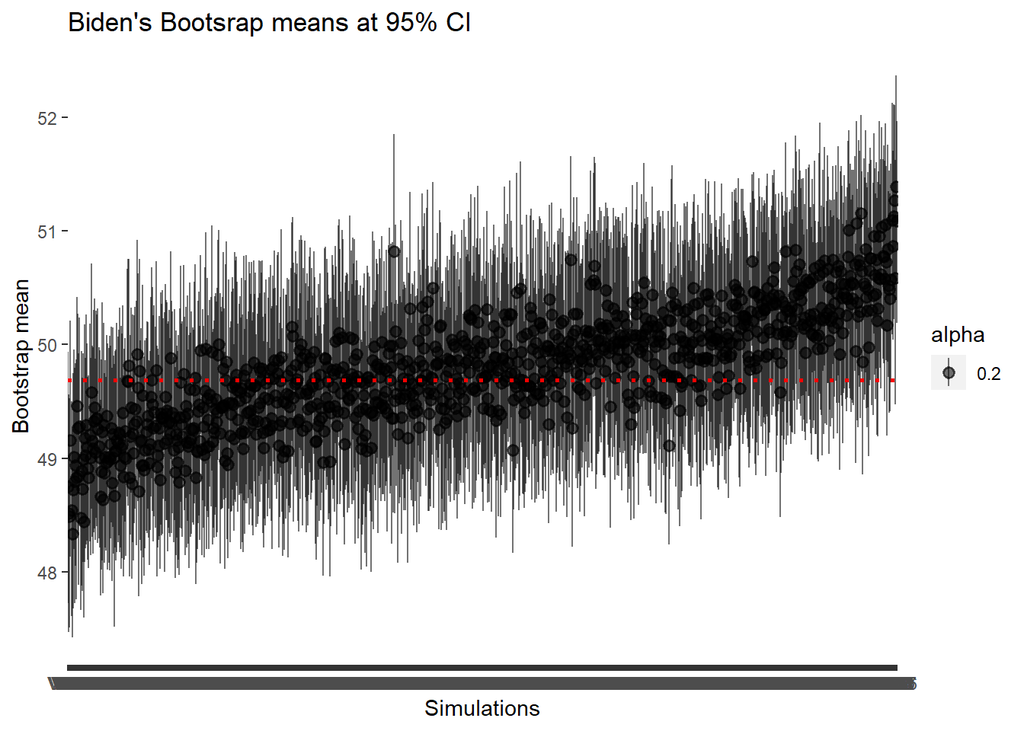

```r
samp_draws_long %>%
  # For EC; Use mutate and fct_reorder function to sort stats in order from low to high
  mutate(ordered_simulation = fct_reorder(simulation, boot_mean)) %>%
# use ggplot to plot the bootstrapped mean and CI for each simulation
ggplot(aes(x = ordered_simulation,
           y = boot_mean,     # setting ggplot mapping and aes
           alpha = 0.2)) +
  stat_summary(fun.data = "mean_cl_boot") +
  # To indicate the initial mean on the plot
  geom_hline(yintercept = mean(biden_avg_polls), linetype="dotted",
                color = "red", size=1) +
  labs(x = "Simulations", y = "Bootstrap mean", title = "Biden's Bootsrap means at 95% CI")
```

```r
# determine the length of all boot means greater than the initial mean (49.63147)
greater_than_mean_boot <- samp_draws_long %>%
  select(boot_mean) %>%
   filter(boot_mean > 49.63147)

# calculate the probability of of having a boot mean higher than the initial mean
prob_of_higher_boot <- length(greater_than_mean_boot)/length(samp_draws_long$boot_mean)

prob_of_higher_boot
```

```
## [1] 2e-05
```

**5d.** So…. what is that plot showing? What are the concepts involved?

The plot shows the bootstrap mean for each simulation at an interval of 95%. The concept involves estimating the bias or variance between each bootstrapped mean and the original mean in order to estimate prediction errors.

**EC** 3 bonus point for each awesome quality visualization of the general polling data. There is a LOT there, so look carefully before you leap.

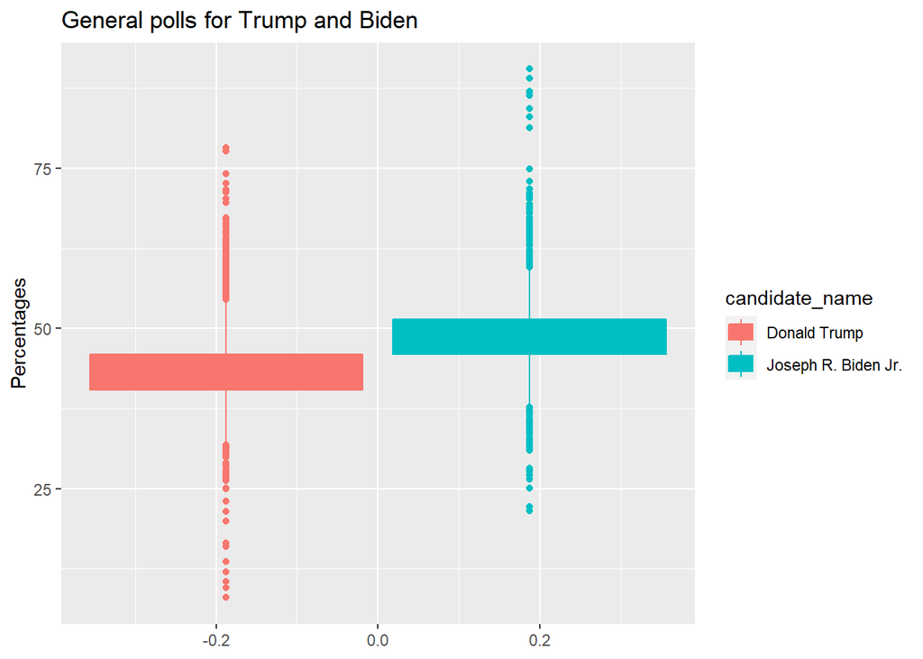

```r
# visualization of the general polling data for Trump and Biden

trump_biden <- president_polls %>%
  # filtered out Trump and Biden's polling data
  filter(candidate_name %in% c("Donald Trump", "Joseph R. Biden Jr."))
# plot average polling percentage nationwide for each candidate
  ggplot(data = trump_biden,
         mapping = aes(y = pct,
             fill = candidate_name,
             colour = candidate_name)) +
    geom_boxplot() +
  labs(y ="Percentages",
     title = "General polls for Trump and Biden")
```

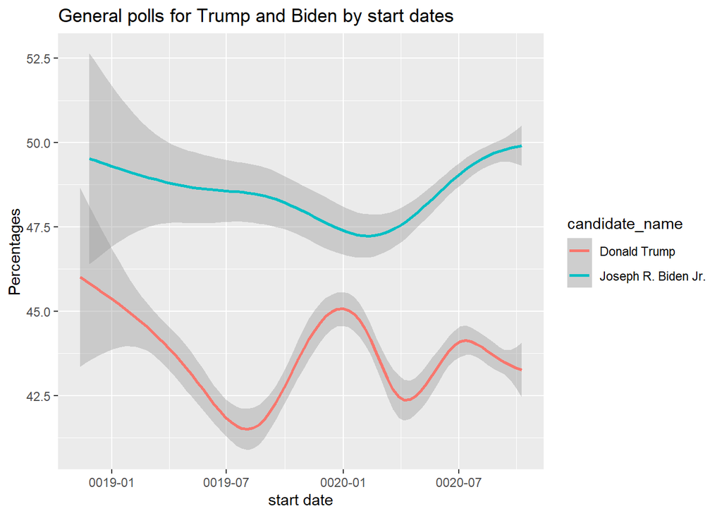

```r
# plot a smooth curve for both candidates by start dates
ggplot(data = trump_biden,
         mapping = aes(x = start_date,
                       y = pct,
                       colour = candidate_name)) +
  geom_smooth() +
  labs(x = "start date", y ="Percentages",
     title = "General polls for Trump and Biden by start dates")
```

[GitHub Extra Credit](https://github.com/Uzezi93/BIOL-607-Homework-Fall-2020-/blob/master/04_OKINEDO_UZEZI_2020.md)